Zajecia z Pythona, czwartek 18:00

Link do spotkania: https://meet.google.com/icv-zhdq-oaw

Lekcja 08.04.2021 - podstawy Jupyter Notebook + Pandas, instalacja środowiska Anaconda, pobranie zbioru danych z serwisu Kaggle.com

# Poruszanie się po Jupyter Notebook

DD - usuniecie komórki

A - dodanie komórki u góry

B - dodanie komórki u dołu

ESC - wyjście z komórki (dezaktywacja komórki)

Enter - wejście w komórke (aktywacja komórki)

Strzałki góra/dół - poruszanie sie po komórkach

Shift + Enter - uruchomienie kodu i przeskoczenie do nastepnej komorki

Ctrl + Enter - uruchomienie kodu i zostanie w tej samej komórce

Ctrl + S - zapisywanie

Shift + Tab - włączanie podpowiedzi kodu

Ctrl + H - wszystkie dostępne skróty

```python
#Import biblioteki pandas, jest to biblioteka do przetwarzania danych

import pandas as pd
```

```python
#Ustawienie opcji wyświetlania maksymalnej ilości obserwacji / kolumn w DataFrame

pd.set_option('display.max_rows', 1000)
pd.set_option('display.max_columns', 50)
```

```python
#Wczytanie zbioru danych o Pokemonach z pliku CSV

df = pd.read_csv('Pokemon.csv')
```

```python
type(df)
```

```
pandas.core.frame.DataFrame
```

```python
#Pierwsze N obserwacji ze zbioru

df.head()
```

|  | # | Name | Type 1 | Type 2 | Total | HP | Attack | Defense | Sp. Atk | Sp. Def | Speed | Generation | Legendary |
| --- | --- | --- | --- | --- | --- | --- | --- | --- | --- | --- | --- | --- | --- |
| 0 | 1 | Bulbasaur | Grass | Poison | 318 | 45 | 49 | 49 | 65 | 65 | 45 | 1 | False |
| 1 | 2 | Ivysaur | Grass | Poison | 405 | 60 | 62 | 63 | 80 | 80 | 60 | 1 | False |
| 2 | 3 | Venusaur | Grass | Poison | 525 | 80 | 82 | 83 | 100 | 100 | 80 | 1 | False |
| 3 | 3 | VenusaurMega Venusaur | Grass | Poison | 625 | 80 | 100 | 123 | 122 | 120 | 80 | 1 | False |
| 4 | 4 | Charmander | Fire | NaN | 309 | 39 | 52 | 43 | 60 | 50 | 65 | 1 | False |

```python
#Ostatnie N obserwacji ze zbioru

df.tail()
```

|  | # | Name | Type 1 | Type 2 | Total | HP | Attack | Defense | Sp. Atk | Sp. Def | Speed | Generation | Legendary |
| --- | --- | --- | --- | --- | --- | --- | --- | --- | --- | --- | --- | --- | --- |
| 795 | 719 | Diancie | Rock | Fairy | 600 | 50 | 100 | 150 | 100 | 150 | 50 | 6 | True |
| 796 | 719 | DiancieMega Diancie | Rock | Fairy | 700 | 50 | 160 | 110 | 160 | 110 | 110 | 6 | True |
| 797 | 720 | HoopaHoopa Confined | Psychic | Ghost | 600 | 80 | 110 | 60 | 150 | 130 | 70 | 6 | True |
| 798 | 720 | HoopaHoopa Unbound | Psychic | Dark | 680 | 80 | 160 | 60 | 170 | 130 | 80 | 6 | True |
| 799 | 721 | Volcanion | Fire | Water | 600 | 80 | 110 | 120 | 130 | 90 | 70 | 6 | True |

```python
#Podsumowanie informacji nt. zbioru danych

df.info()
```

```
<class 'pandas.core.frame.DataFrame'>
RangeIndex: 800 entries, 0 to 799
Data columns (total 13 columns):
 #   Column      Non-Null Count  Dtype
---  ------      --------------  -----
 0   #           800 non-null    int64
 1   Name        800 non-null    object
 2   Type 1      800 non-null    object
 3   Type 2      414 non-null    object
 4   Total       800 non-null    int64
 5   HP          800 non-null    int64
 6   Attack      800 non-null    int64
 7   Defense     800 non-null    int64
 8   Sp. Atk     800 non-null    int64
 9   Sp. Def     800 non-null    int64
 10  Speed       800 non-null    int64
 11  Generation  800 non-null    int64
 12  Legendary   800 non-null    bool
dtypes: bool(1), int64(9), object(3)
memory usage: 75.9+ KB
```

```python
#Sprawdzanie wartości brakujących tzw. missingów

df.isnull().sum()

#Inne opcje

#df.isna().sum()
#df.isna().any()
#df.isna().all()
```

```
#               0
Name            0
Type 1          0
Type 2        386
Total           0
HP              0
Attack          0
Defense         0
Sp. Atk         0
Sp. Def         0
Speed           0
Generation      0
Legendary       0
dtype: int64
```

```python
#Podstawowe statystyki opisowe (średnia, mediana, ilość, wartość maksymalna, wartość minimalna itp.) dla kolumn numerycznych

df.describe()
```

|  | # | Total | HP | Attack | Defense | Sp. Atk | Sp. Def | Speed | Generation |
| --- | --- | --- | --- | --- | --- | --- | --- | --- | --- |
| count | 800.000000 | 800.00000 | 800.000000 | 800.000000 | 800.000000 | 800.000000 | 800.000000 | 800.000000 | 800.00000 |
| mean | 362.813750 | 435.10250 | 69.258750 | 79.001250 | 73.842500 | 72.820000 | 71.902500 | 68.277500 | 3.32375 |
| std | 208.343798 | 119.96304 | 25.534669 | 32.457366 | 31.183501 | 32.722294 | 27.828916 | 29.060474 | 1.66129 |
| min | 1.000000 | 180.00000 | 1.000000 | 5.000000 | 5.000000 | 10.000000 | 20.000000 | 5.000000 | 1.00000 |
| 25% | 184.750000 | 330.00000 | 50.000000 | 55.000000 | 50.000000 | 49.750000 | 50.000000 | 45.000000 | 2.00000 |
| 50% | 364.500000 | 450.00000 | 65.000000 | 75.000000 | 70.000000 | 65.000000 | 70.000000 | 65.000000 | 3.00000 |
| 75% | 539.250000 | 515.00000 | 80.000000 | 100.000000 | 90.000000 | 95.000000 | 90.000000 | 90.000000 | 5.00000 |
| max | 721.000000 | 780.00000 | 255.000000 | 190.000000 | 230.000000 | 194.000000 | 230.000000 | 180.000000 | 6.00000 |

```python
#Filtrowanie po obserwacjach, funkcje .loc i .iloc (do późniejszego omówienia)

df.loc[1]
```

```
#                   2
Name          Ivysaur
Type 1          Grass
Type 2         Poison
Total             405
HP                 60
Attack             62
Defense            63
Sp. Atk            80
Sp. Def            80
Speed              60
Generation          1
Legendary       False
Name: 1, dtype: object
```

```python
#Series
print(type(df['Name']))
#Dataframe
print(type(df[['Name','Type 1']]))
```

```
<class 'pandas.core.series.Series'>
<class 'pandas.core.frame.DataFrame'>
```

```python
#Wybór jednej kolumny z DataFrame - pojedyńczy nawias kwadratowy
df['Name']
```

```
0                      Bulbasaur
1                        Ivysaur
2                       Venusaur
3          VenusaurMega Venusaur
4                     Charmander
5                     Charmeleon
6                      Charizard
7      CharizardMega Charizard X
8      CharizardMega Charizard Y
9                       Squirtle
10                     Wartortle
11                     Blastoise
12       BlastoiseMega Blastoise
13                      Caterpie
14                       Metapod
```

[output cut: 786 more lines]

```python
#Wybór wielu kolumn - podwójne nawiasy kwadratowe
df[['Name','Type 1','Sp. Def']]
```

|  | Name | Type 1 | Sp. Def |
| --- | --- | --- | --- |
| 0 | Bulbasaur | Grass | 65 |
| 1 | Ivysaur | Grass | 80 |
| 2 | Venusaur | Grass | 100 |
| 3 | VenusaurMega Venusaur | Grass | 120 |
| 4 | Charmander | Fire | 50 |
| 5 | Charmeleon | Fire | 65 |
| 6 | Charizard | Fire | 85 |
| 7 | CharizardMega Charizard X | Fire | 85 |
| 8 | CharizardMega Charizard Y | Fire | 115 |
| 9 | Squirtle | Water | 64 |
| 10 | Wartortle | Water | 80 |
| 11 | Blastoise | Water | 105 |
| 12 | BlastoiseMega Blastoise | Water | 115 |
| 13 | Caterpie | Bug | 20 |
| 14 | Metapod | Bug | 25 |
| 15 | Butterfree | Bug | 80 |
| 16 | Weedle | Bug | 20 |
| 17 | Kakuna | Bug | 25 |
| 18 | Beedrill | Bug | 80 |
| 19 | BeedrillMega Beedrill | Bug | 80 |
| 20 | Pidgey | Normal | 35 |
| 21 | Pidgeotto | Normal | 50 |
| 22 | Pidgeot | Normal | 70 |
| 23 | PidgeotMega Pidgeot | Normal | 80 |
| 24 | Rattata | Normal | 35 |
| 25 | Raticate | Normal | 70 |
| 26 | Spearow | Normal | 31 |
| 27 | Fearow | Normal | 61 |
| 28 | Ekans | Poison | 54 |
| 29 | Arbok | Poison | 79 |

[output cut: 770 more lines]

Lekcja 15.04.2021 - tematy do omówienia :

1. zmiana nazw kolumn w DataFrame
2. Tworzenie nowych kolumn w DataFrame
3. filtrowanie obserwacji po kolumnach / obserwacjach, funkcje .loc, .iloc + operatory logiczne
4. łączenie zbiorów, concat, merge, join
5. Uzupełnianie brakujących danych (różne metody)
6. wizualizacja/wykresy w Pandas
7. wizualizacja/wykresy w Seaborn
8. wizualizacja/wykresy 3D w Plotly (+ instalcja bibliotek w Anaconda)

```python
df = df.rename(columns={'Type 1':'Type_1', 'Type 2':'Type_2'})
```

```python
df.head(1)
```

|  | # | Name | Type_1 | Type_2 | Total | HP | Attack | Defense | Sp. Atk | Sp. Def | Speed | Generation | Legendary |
| --- | --- | --- | --- | --- | --- | --- | --- | --- | --- | --- | --- | --- | --- |
| 0 | 1 | Bulbasaur | Grass | Poison | 318 | 45 | 49 | 49 | 65 | 65 | 45 | 1 | False |

```python
type(df)
```

```
pandas.core.frame.DataFrame
```

```python
df['2HP'] = df['HP']*2
```

```python
df['Nowa_Kolumna'] = 'Tak, Nie'
```

```python
#Filtrowanie
```

```python
df.iloc[]

df.loc[]
```

```python
#Operator AND
df.loc[(df['Attack'] > 50) & (df['Defense'] > 100)]
```

|  | # | Name | Type_1 | Type_2 | Total | HP | Attack | Defense | Sp. Atk | Sp. Def | Speed | Generation | Legendary | 2HP | Nowa_Kolumna |
| --- | --- | --- | --- | --- | --- | --- | --- | --- | --- | --- | --- | --- | --- | --- | --- |
| 3 | 3 | VenusaurMega Venusaur | Grass | Poison | 625 | 80 | 100 | 123 | 122 | 120 | 80 | 1 | False | 160 | Tak, Nie |
| 7 | 6 | CharizardMega Charizard X | Fire | Dragon | 634 | 78 | 130 | 111 | 130 | 85 | 100 | 1 | False | 156 | Tak, Nie |
| 12 | 9 | BlastoiseMega Blastoise | Water | NaN | 630 | 79 | 103 | 120 | 135 | 115 | 78 | 1 | False | 158 | Tak, Nie |
| 33 | 28 | Sandslash | Ground | NaN | 450 | 75 | 100 | 110 | 45 | 55 | 65 | 1 | False | 150 | Tak, Nie |
| 81 | 75 | Graveler | Rock | Ground | 390 | 55 | 95 | 115 | 45 | 45 | 35 | 1 | False | 110 | Tak, Nie |
| 82 | 76 | Golem | Rock | Ground | 495 | 80 | 120 | 130 | 55 | 65 | 45 | 1 | False | 160 | Tak, Nie |
| 86 | 80 | Slowbro | Water | Psychic | 490 | 95 | 75 | 110 | 100 | 80 | 30 | 1 | False | 190 | Tak, Nie |
| 87 | 80 | SlowbroMega Slowbro | Water | Psychic | 590 | 95 | 75 | 180 | 130 | 80 | 30 | 1 | False | 190 | Tak, Nie |
| 98 | 91 | Cloyster | Water | Ice | 525 | 50 | 95 | 180 | 85 | 45 | 70 | 1 | False | 100 | Tak, Nie |
| 107 | 99 | Kingler | Water | NaN | 475 | 55 | 130 | 115 | 50 | 50 | 75 | 1 | False | 110 | Tak, Nie |
| 113 | 105 | Marowak | Ground | NaN | 425 | 60 | 80 | 110 | 50 | 80 | 45 | 1 | False | 120 | Tak, Nie |
| 118 | 110 | Weezing | Poison | NaN | 490 | 65 | 90 | 120 | 85 | 70 | 60 | 1 | False | 130 | Tak, Nie |
| 120 | 112 | Rhydon | Ground | Rock | 485 | 105 | 130 | 120 | 45 | 45 | 40 | 1 | False | 210 | Tak, Nie |
| 122 | 114 | Tangela | Grass | NaN | 435 | 65 | 55 | 115 | 100 | 40 | 60 | 1 | False | 130 | Tak, Nie |
| 137 | 127 | PinsirMega Pinsir | Bug | Flying | 600 | 65 | 155 | 120 | 65 | 90 | 105 | 1 | False | 130 | Tak, Nie |
| 141 | 130 | GyaradosMega Gyarados | Water | Dark | 640 | 95 | 155 | 109 | 70 | 130 | 81 | 1 | False | 190 | Tak, Nie |
| 150 | 139 | Omastar | Rock | Water | 495 | 70 | 60 | 125 | 115 | 70 | 55 | 1 | False | 140 | Tak, Nie |
| 152 | 141 | Kabutops | Rock | Water | 495 | 60 | 115 | 105 | 65 | 70 | 80 | 1 | False | 120 | Tak, Nie |
| 196 | 181 | AmpharosMega Ampharos | Electric | Dragon | 610 | 90 | 95 | 105 | 165 | 110 | 45 | 2 | False | 180 | Tak, Nie |
| 200 | 185 | Sudowoodo | Rock | NaN | 410 | 70 | 100 | 115 | 30 | 65 | 30 | 2 | False | 140 | Tak, Nie |
| 212 | 197 | Umbreon | Dark | NaN | 525 | 95 | 65 | 110 | 60 | 130 | 65 | 2 | False | 190 | Tak, Nie |
| 220 | 205 | Forretress | Bug | Steel | 465 | 75 | 90 | 140 | 60 | 60 | 40 | 2 | False | 150 | Tak, Nie |
| 222 | 207 | Gligar | Ground | Flying | 430 | 65 | 75 | 105 | 35 | 65 | 85 | 2 | False | 130 | Tak, Nie |
| 223 | 208 | Steelix | Steel | Ground | 510 | 75 | 85 | 200 | 55 | 65 | 30 | 2 | False | 150 | Tak, Nie |
| 224 | 208 | SteelixMega Steelix | Steel | Ground | 610 | 75 | 125 | 230 | 55 | 95 | 30 | 2 | False | 150 | Tak, Nie |
| 229 | 212 | ScizorMega Scizor | Bug | Steel | 600 | 70 | 150 | 140 | 65 | 100 | 75 | 2 | False | 140 | Tak, Nie |
| 232 | 214 | HeracrossMega Heracross | Bug | Fighting | 600 | 80 | 185 | 115 | 40 | 105 | 75 | 2 | False | 160 | Tak, Nie |
| 245 | 227 | Skarmory | Steel | Flying | 465 | 65 | 80 | 140 | 40 | 70 | 70 | 2 | False | 130 | Tak, Nie |
| 251 | 232 | Donphan | Ground | NaN | 500 | 90 | 120 | 120 | 60 | 60 | 50 | 2 | False | 180 | Tak, Nie |
| 260 | 241 | Miltank | Normal | NaN | 490 | 95 | 80 | 105 | 40 | 70 | 100 | 2 | False | 190 | Tak, Nie |

[output cut: 84 more lines]

```python
#Operator OR
df.loc[(df['Attack'] > 50) |
       (df['Defense'] > 100) |
       (df['HP'] >= 150)]
```

|  | # | Name | Type_1 | Type_2 | Total | HP | Attack | Defense | Sp. Atk | Sp. Def | Speed | Generation | Legendary | 2HP | Nowa_Kolumna |
| --- | --- | --- | --- | --- | --- | --- | --- | --- | --- | --- | --- | --- | --- | --- | --- |
| 1 | 2 | Ivysaur | Grass | Poison | 405 | 60 | 62 | 63 | 80 | 80 | 60 | 1 | False | 120 | Tak, Nie |
| 2 | 3 | Venusaur | Grass | Poison | 525 | 80 | 82 | 83 | 100 | 100 | 80 | 1 | False | 160 | Tak, Nie |
| 3 | 3 | VenusaurMega Venusaur | Grass | Poison | 625 | 80 | 100 | 123 | 122 | 120 | 80 | 1 | False | 160 | Tak, Nie |
| 4 | 4 | Charmander | Fire | NaN | 309 | 39 | 52 | 43 | 60 | 50 | 65 | 1 | False | 78 | Tak, Nie |
| 5 | 5 | Charmeleon | Fire | NaN | 405 | 58 | 64 | 58 | 80 | 65 | 80 | 1 | False | 116 | Tak, Nie |
| 6 | 6 | Charizard | Fire | Flying | 534 | 78 | 84 | 78 | 109 | 85 | 100 | 1 | False | 156 | Tak, Nie |
| 7 | 6 | CharizardMega Charizard X | Fire | Dragon | 634 | 78 | 130 | 111 | 130 | 85 | 100 | 1 | False | 156 | Tak, Nie |
| 8 | 6 | CharizardMega Charizard Y | Fire | Flying | 634 | 78 | 104 | 78 | 159 | 115 | 100 | 1 | False | 156 | Tak, Nie |
| 10 | 8 | Wartortle | Water | NaN | 405 | 59 | 63 | 80 | 65 | 80 | 58 | 1 | False | 118 | Tak, Nie |
| 11 | 9 | Blastoise | Water | NaN | 530 | 79 | 83 | 100 | 85 | 105 | 78 | 1 | False | 158 | Tak, Nie |
| 12 | 9 | BlastoiseMega Blastoise | Water | NaN | 630 | 79 | 103 | 120 | 135 | 115 | 78 | 1 | False | 158 | Tak, Nie |
| 18 | 15 | Beedrill | Bug | Poison | 395 | 65 | 90 | 40 | 45 | 80 | 75 | 1 | False | 130 | Tak, Nie |
| 19 | 15 | BeedrillMega Beedrill | Bug | Poison | 495 | 65 | 150 | 40 | 15 | 80 | 145 | 1 | False | 130 | Tak, Nie |
| 21 | 17 | Pidgeotto | Normal | Flying | 349 | 63 | 60 | 55 | 50 | 50 | 71 | 1 | False | 126 | Tak, Nie |
| 22 | 18 | Pidgeot | Normal | Flying | 479 | 83 | 80 | 75 | 70 | 70 | 101 | 1 | False | 166 | Tak, Nie |
| 23 | 18 | PidgeotMega Pidgeot | Normal | Flying | 579 | 83 | 80 | 80 | 135 | 80 | 121 | 1 | False | 166 | Tak, Nie |
| 24 | 19 | Rattata | Normal | NaN | 253 | 30 | 56 | 35 | 25 | 35 | 72 | 1 | False | 60 | Tak, Nie |
| 25 | 20 | Raticate | Normal | NaN | 413 | 55 | 81 | 60 | 50 | 70 | 97 | 1 | False | 110 | Tak, Nie |
| 26 | 21 | Spearow | Normal | Flying | 262 | 40 | 60 | 30 | 31 | 31 | 70 | 1 | False | 80 | Tak, Nie |
| 27 | 22 | Fearow | Normal | Flying | 442 | 65 | 90 | 65 | 61 | 61 | 100 | 1 | False | 130 | Tak, Nie |
| 28 | 23 | Ekans | Poison | NaN | 288 | 35 | 60 | 44 | 40 | 54 | 55 | 1 | False | 70 | Tak, Nie |
| 29 | 24 | Arbok | Poison | NaN | 438 | 60 | 85 | 69 | 65 | 79 | 80 | 1 | False | 120 | Tak, Nie |
| 30 | 25 | Pikachu | Electric | NaN | 320 | 35 | 55 | 40 | 50 | 50 | 90 | 1 | False | 70 | Tak, Nie |
| 31 | 26 | Raichu | Electric | NaN | 485 | 60 | 90 | 55 | 90 | 80 | 110 | 1 | False | 120 | Tak, Nie |
| 32 | 27 | Sandshrew | Ground | NaN | 300 | 50 | 75 | 85 | 20 | 30 | 40 | 1 | False | 100 | Tak, Nie |
| 33 | 28 | Sandslash | Ground | NaN | 450 | 75 | 100 | 110 | 45 | 55 | 65 | 1 | False | 150 | Tak, Nie |
| 35 | 30 | Nidorina | Poison | NaN | 365 | 70 | 62 | 67 | 55 | 55 | 56 | 1 | False | 140 | Tak, Nie |
| 36 | 31 | Nidoqueen | Poison | Ground | 505 | 90 | 92 | 87 | 75 | 85 | 76 | 1 | False | 180 | Tak, Nie |
| 37 | 32 | Nidoran♂ | Poison | NaN | 273 | 46 | 57 | 40 | 40 | 40 | 50 | 1 | False | 92 | Tak, Nie |
| 38 | 33 | Nidorino | Poison | NaN | 365 | 61 | 72 | 57 | 55 | 55 | 65 | 1 | False | 122 | Tak, Nie |

[output cut: 612 more lines]

```python
df.loc[df['Generation'] == 1 ]
```

|  | # | Name | Type_1 | Type_2 | Total | HP | Attack | Defense | Sp. Atk | Sp. Def | Speed | Generation | Legendary | 2HP | Nowa_Kolumna |
| --- | --- | --- | --- | --- | --- | --- | --- | --- | --- | --- | --- | --- | --- | --- | --- |
| 0 | 1 | Bulbasaur | Grass | Poison | 318 | 45 | 49 | 49 | 65 | 65 | 45 | 1 | False | 90 | Tak, Nie |
| 1 | 2 | Ivysaur | Grass | Poison | 405 | 60 | 62 | 63 | 80 | 80 | 60 | 1 | False | 120 | Tak, Nie |
| 2 | 3 | Venusaur | Grass | Poison | 525 | 80 | 82 | 83 | 100 | 100 | 80 | 1 | False | 160 | Tak, Nie |
| 3 | 3 | VenusaurMega Venusaur | Grass | Poison | 625 | 80 | 100 | 123 | 122 | 120 | 80 | 1 | False | 160 | Tak, Nie |
| 4 | 4 | Charmander | Fire | NaN | 309 | 39 | 52 | 43 | 60 | 50 | 65 | 1 | False | 78 | Tak, Nie |
| 5 | 5 | Charmeleon | Fire | NaN | 405 | 58 | 64 | 58 | 80 | 65 | 80 | 1 | False | 116 | Tak, Nie |
| 6 | 6 | Charizard | Fire | Flying | 534 | 78 | 84 | 78 | 109 | 85 | 100 | 1 | False | 156 | Tak, Nie |
| 7 | 6 | CharizardMega Charizard X | Fire | Dragon | 634 | 78 | 130 | 111 | 130 | 85 | 100 | 1 | False | 156 | Tak, Nie |
| 8 | 6 | CharizardMega Charizard Y | Fire | Flying | 634 | 78 | 104 | 78 | 159 | 115 | 100 | 1 | False | 156 | Tak, Nie |
| 9 | 7 | Squirtle | Water | NaN | 314 | 44 | 48 | 65 | 50 | 64 | 43 | 1 | False | 88 | Tak, Nie |
| 10 | 8 | Wartortle | Water | NaN | 405 | 59 | 63 | 80 | 65 | 80 | 58 | 1 | False | 118 | Tak, Nie |
| 11 | 9 | Blastoise | Water | NaN | 530 | 79 | 83 | 100 | 85 | 105 | 78 | 1 | False | 158 | Tak, Nie |
| 12 | 9 | BlastoiseMega Blastoise | Water | NaN | 630 | 79 | 103 | 120 | 135 | 115 | 78 | 1 | False | 158 | Tak, Nie |
| 13 | 10 | Caterpie | Bug | NaN | 195 | 45 | 30 | 35 | 20 | 20 | 45 | 1 | False | 90 | Tak, Nie |
| 14 | 11 | Metapod | Bug | NaN | 205 | 50 | 20 | 55 | 25 | 25 | 30 | 1 | False | 100 | Tak, Nie |
| 15 | 12 | Butterfree | Bug | Flying | 395 | 60 | 45 | 50 | 90 | 80 | 70 | 1 | False | 120 | Tak, Nie |
| 16 | 13 | Weedle | Bug | Poison | 195 | 40 | 35 | 30 | 20 | 20 | 50 | 1 | False | 80 | Tak, Nie |
| 17 | 14 | Kakuna | Bug | Poison | 205 | 45 | 25 | 50 | 25 | 25 | 35 | 1 | False | 90 | Tak, Nie |
| 18 | 15 | Beedrill | Bug | Poison | 395 | 65 | 90 | 40 | 45 | 80 | 75 | 1 | False | 130 | Tak, Nie |
| 19 | 15 | BeedrillMega Beedrill | Bug | Poison | 495 | 65 | 150 | 40 | 15 | 80 | 145 | 1 | False | 130 | Tak, Nie |
| 20 | 16 | Pidgey | Normal | Flying | 251 | 40 | 45 | 40 | 35 | 35 | 56 | 1 | False | 80 | Tak, Nie |
| 21 | 17 | Pidgeotto | Normal | Flying | 349 | 63 | 60 | 55 | 50 | 50 | 71 | 1 | False | 126 | Tak, Nie |
| 22 | 18 | Pidgeot | Normal | Flying | 479 | 83 | 80 | 75 | 70 | 70 | 101 | 1 | False | 166 | Tak, Nie |
| 23 | 18 | PidgeotMega Pidgeot | Normal | Flying | 579 | 83 | 80 | 80 | 135 | 80 | 121 | 1 | False | 166 | Tak, Nie |
| 24 | 19 | Rattata | Normal | NaN | 253 | 30 | 56 | 35 | 25 | 35 | 72 | 1 | False | 60 | Tak, Nie |
| 25 | 20 | Raticate | Normal | NaN | 413 | 55 | 81 | 60 | 50 | 70 | 97 | 1 | False | 110 | Tak, Nie |
| 26 | 21 | Spearow | Normal | Flying | 262 | 40 | 60 | 30 | 31 | 31 | 70 | 1 | False | 80 | Tak, Nie |
| 27 | 22 | Fearow | Normal | Flying | 442 | 65 | 90 | 65 | 61 | 61 | 100 | 1 | False | 130 | Tak, Nie |
| 28 | 23 | Ekans | Poison | NaN | 288 | 35 | 60 | 44 | 40 | 54 | 55 | 1 | False | 70 | Tak, Nie |
| 29 | 24 | Arbok | Poison | NaN | 438 | 60 | 85 | 69 | 65 | 79 | 80 | 1 | False | 120 | Tak, Nie |

[output cut: 136 more lines]

```python
df.iloc[400:500,[0,2,3]]
```

|  | # | Type_1 | Type_2 |
| --- | --- | --- | --- |
| 400 | 365 | Ice | Water |
| 401 | 366 | Water | NaN |
| 402 | 367 | Water | NaN |
| 403 | 368 | Water | NaN |
| 404 | 369 | Water | Rock |
| 405 | 370 | Water | NaN |
| 406 | 371 | Dragon | NaN |
| 407 | 372 | Dragon | NaN |
| 408 | 373 | Dragon | Flying |
| 409 | 373 | Dragon | Flying |
| 410 | 374 | Steel | Psychic |
| 411 | 375 | Steel | Psychic |
| 412 | 376 | Steel | Psychic |
| 413 | 376 | Steel | Psychic |
| 414 | 377 | Rock | NaN |
| 415 | 378 | Ice | NaN |
| 416 | 379 | Steel | NaN |
| 417 | 380 | Dragon | Psychic |
| 418 | 380 | Dragon | Psychic |
| 419 | 381 | Dragon | Psychic |
| 420 | 381 | Dragon | Psychic |
| 421 | 382 | Water | NaN |
| 422 | 382 | Water | NaN |
| 423 | 383 | Ground | NaN |
| 424 | 383 | Ground | Fire |
| 425 | 384 | Dragon | Flying |
| 426 | 384 | Dragon | Flying |
| 427 | 385 | Steel | Psychic |
| 428 | 386 | Psychic | NaN |
| 429 | 386 | Psychic | NaN |

[output cut: 70 more lines]

```python
temp1 = df.iloc[0:100,:]
temp2 = df.iloc[100:200,:]
temp3 = df.iloc[200:300,:]
```

```python
total = pd.concat([temp1,temp2,temp3])
```

```python
temp1 = df[['Name','Type_1','HP']]
```

```python
temp2 = df[['Name','Type_2','Attack']]
```

```python
temp1.head()
```

|  | Name | Type_1 | HP |
| --- | --- | --- | --- |
| 0 | Bulbasaur | Grass | 45 |
| 1 | Ivysaur | Grass | 60 |
| 2 | Venusaur | Grass | 80 |
| 3 | VenusaurMega Venusaur | Grass | 80 |
| 4 | Charmander | Fire | 39 |

```python
temp2.head()
```

|  | Name | Type_2 | Attack |
| --- | --- | --- | --- |
| 0 | Bulbasaur | Poison | 49 |
| 1 | Ivysaur | Poison | 62 |
| 2 | Venusaur | Poison | 82 |
| 3 | VenusaurMega Venusaur | Poison | 100 |
| 4 | Charmander | NaN | 52 |

```python
pd.merge(temp1,temp2,on='Name')
```

|  | Name | Type_1 | HP | Type_2 | Attack |
| --- | --- | --- | --- | --- | --- |
| 0 | Bulbasaur | Grass | 45 | Poison | 49 |
| 1 | Ivysaur | Grass | 60 | Poison | 62 |
| 2 | Venusaur | Grass | 80 | Poison | 82 |
| 3 | VenusaurMega Venusaur | Grass | 80 | Poison | 100 |
| 4 | Charmander | Fire | 39 | NaN | 52 |
| 5 | Charmeleon | Fire | 58 | NaN | 64 |
| 6 | Charizard | Fire | 78 | Flying | 84 |
| 7 | CharizardMega Charizard X | Fire | 78 | Dragon | 130 |
| 8 | CharizardMega Charizard Y | Fire | 78 | Flying | 104 |
| 9 | Squirtle | Water | 44 | NaN | 48 |
| 10 | Wartortle | Water | 59 | NaN | 63 |
| 11 | Blastoise | Water | 79 | NaN | 83 |
| 12 | BlastoiseMega Blastoise | Water | 79 | NaN | 103 |
| 13 | Caterpie | Bug | 45 | NaN | 30 |
| 14 | Metapod | Bug | 50 | NaN | 20 |
| 15 | Butterfree | Bug | 60 | Flying | 45 |
| 16 | Weedle | Bug | 40 | Poison | 35 |
| 17 | Kakuna | Bug | 45 | Poison | 25 |
| 18 | Beedrill | Bug | 65 | Poison | 90 |
| 19 | BeedrillMega Beedrill | Bug | 65 | Poison | 150 |
| 20 | Pidgey | Normal | 40 | Flying | 45 |
| 21 | Pidgeotto | Normal | 63 | Flying | 60 |
| 22 | Pidgeot | Normal | 83 | Flying | 80 |
| 23 | PidgeotMega Pidgeot | Normal | 83 | Flying | 80 |
| 24 | Rattata | Normal | 30 | NaN | 56 |
| 25 | Raticate | Normal | 55 | NaN | 81 |
| 26 | Spearow | Normal | 40 | Flying | 60 |
| 27 | Fearow | Normal | 65 | Flying | 90 |
| 28 | Ekans | Poison | 35 | NaN | 60 |
| 29 | Arbok | Poison | 60 | NaN | 85 |

[output cut: 770 more lines]

```python
df.isnull().sum()
```

```
#                 0
Name              0
Type_1            0
Type_2          386
Total             0
HP                0
Attack            0
Defense           0
Sp. Atk           0
Sp. Def           0
Speed             0
Generation        0
Legendary         0
2HP               0
Nowa_Kolumna      0
dtype: int64
```

```python
df['Type_2'].fillna(value='None')
```

```
0        Poison
1        Poison
2        Poison
3        Poison
4          None
5          None
6        Flying
7        Dragon
8        Flying
9          None
10         None
11         None
12         None
13         None
14         None
```

[output cut: 786 more lines]

```python
df['Type_2'].fillna(method='ffill')
```

```
0        Poison
1        Poison
2        Poison
3        Poison
4        Poison
5        Poison
6        Flying
7        Dragon
8        Flying
9        Flying
10       Flying
11       Flying
12       Flying
13       Flying
14       Flying
```

[output cut: 786 more lines]

```python
import seaborn as sns
```

Aplikacja w Dashu.

Funkcjonalności:

- wczytywanie danych z biblioteka Pandas
- uzupelnianie brakujacych danych
- tworzenie wykresów 2D / 3D
- na 1 stronie będzie np. przetwarzanie danych
- na 2 stornie będzie np. wizualizacja danych
- na 3 stronie będzie np. uzupelnianie, tworzenie nowych kolumn

IDE:

- VISUAL STUDIO CODE

BIBLIOTEKI:

- Dash, Plotly, Seaborn, Pandas, Matplotlib, Numpy
- Znaleźć 2-3 zbiory danych (np. na stronie Kaggle.com)

```python
df.head()
```

|  | # | Name | Type 1 | Type 2 | Total | HP | Attack | Defense | Sp. Atk | Sp. Def | Speed | Generation | Legendary |
| --- | --- | --- | --- | --- | --- | --- | --- | --- | --- | --- | --- | --- | --- |
| 0 | 1 | Bulbasaur | Grass | Poison | 318 | 45 | 49 | 49 | 65 | 65 | 45 | 1 | False |
| 1 | 2 | Ivysaur | Grass | Poison | 405 | 60 | 62 | 63 | 80 | 80 | 60 | 1 | False |
| 2 | 3 | Venusaur | Grass | Poison | 525 | 80 | 82 | 83 | 100 | 100 | 80 | 1 | False |
| 3 | 3 | VenusaurMega Venusaur | Grass | Poison | 625 | 80 | 100 | 123 | 122 | 120 | 80 | 1 | False |
| 4 | 4 | Charmander | Fire | NaN | 309 | 39 | 52 | 43 | 60 | 50 | 65 | 1 | False |

```python
import seaborn as sns
```

```python
df.shape
```

```
(800, 13)
```

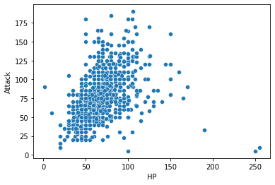

```python
sns.scatterplot(x=df['HP'], y=df['Attack'] )
```